# Project 1: Biomedical & Clinical Informatics

### 3.2.1 Use the `md.pairs()` function from the `mice` package to assess the extent of missing values before imputing.

When we are missing a lot of data, as we are here, it can sometimes be useful to predetermine whether the *patterns of missing correlate with our target*. Why? We care if missing values correlate with the target because this may indicate that the missingness itself carries information. Thus, ignoring it could lead to biased models or low predictive power!

In fact, missingness can itself **become a predictor**. If a missing value is associated with the outcome, it may carry predictive signal. For example, in our data, hospitals with high rates of missingness in `Left before being seen` highly associated with pneumonia readmission might indicate a worrying pattern. Perhaps hospitals are negligently failing to report how many of their patients leave without being seen because of larger, systemic issues that ALSO happen to impact overall quality and patient care. Thus, missingness could itself become a predictor!

To do, I will leverage the `md.pairs()` function from the `mice` package which calculates the pairwise correlations of missingness between variables and allows us to visualize those patterns using a clustered heatmap. When I do this, I will drop `State` from the matrix because it will create errors if I retain it. (**Why?**)

```r
## Drop State and analyze the pairwise missingness using the mice package
miceMatrix <- dat2Analyze %>% select(-State) %>% md.pairs()
```

What `md.mice()` does is create two pairwise correlation matrices, `mr` and `mm`, where:

- `mr` = **Missing vs. Responded**
  - Pairwise matrix showing how often the row has a missing value in one variable and an observed (i.e., non-missing or “responded”) value in the other
- `mm` = **Missing vs. Missing**
  - Pairwise matrix showing how often the row has a missing value in one variable and missing value in the other variable

Let’s take a look at the first 6 rows and 4 columns of the `mr` matrix:

Table 4. Missing vs. Reponded Matrix Slice

|  | PredictedReadmissionRate | ComparedToNational_MRSA Bacteremia | MRSA Bacteremia | Payment for pneumonia patients |
| --- | --- | --- | --- | --- |
| PredictedReadmissionRate | 0 | 48 | 48 | 630 |
| ComparedToNational_MRSA Bacteremia | 1041 | 0 | 0 | 1650 |
| MRSA Bacteremia | 1041 | 0 | 0 | 1650 |
| Payment for pneumonia patients | 21 | 48 | 48 | 0 |
| Abdomen CT Use of Contrast Material | 37 | 42 | 42 | 69 |
| ComparedToNational_Death rate for pneumonia patients | 10 | 47 | 47 | 6 |

Now, let’s take a look at the first 6 rows and 4 columns of the `mm` matrix now:

Table 5. Missing vs. Missing Matrix Slice

|  | PredictedReadmissionRate | ComparedToNational_MRSA Bacteremia | MRSA Bacteremia | Payment for pneumonia patients |
| --- | --- | --- | --- | --- |
| PredictedReadmissionRate | 2090 | 2042 | 2042 | 1460 |
| ComparedToNational_MRSA Bacteremia | 2042 | 3083 | 3083 | 1433 |
| MRSA Bacteremia | 2042 | 3083 | 3083 | 1433 |
| Payment for pneumonia patients | 1460 | 1433 | 1433 | 1481 |
| Abdomen CT Use of Contrast Material | 852 | 847 | 847 | 820 |
| ComparedToNational_Death rate for pneumonia patients | 1292 | 1255 | 1255 | 1296 |

Similarly, `miceMatrix$mm[i, j]` gives us the number of cases where both variables $i$ and $j$ were co-missing.

#### **Question 11A**: [0.5 points]

Explain what you think the number in cell $[6,1]$ means. Out of all the observations in the dataset, does this feel like a high degree of co-missingness?

> Your answer here. if I am looking at the correct cell, that would be ’Compared to the National Death Rate for pneumonia patients. It is likely a smaller number since not all pneumonia patients will die.

Lastly, we can calculate a **proportion of missingness vs. response** between any two variables $i$ and $j$ such that:

$Proportion_{i,j} = \frac{mr_{i,j}}{mr_{i,j} + mm_{i,j}}$

In non-mathy speak, it’s the fraction of the times that variable $j$ is observed among rows where $i$ is missing. So, if you want to impute variable $i$ - let’s say it’s `MRSA Bacteremia` - then you will be interested in the variables typically **observed** (present in the dataset) when $i$ is missing. Those are the variables that will be able to help us predict, or fill in, $i$.

- If this ratio is close to 1, $j$ is nearly always available when $i$ is missing, so $j$ might be useful for imputing $i$.
- If this ratio is close to 0, $j$ is usually missing when $i$ is missing, so it’s not helpful for imputing $i$. You can also use this to tell you about **patterns of missingness with regard to your target variable when you target is** $i$.

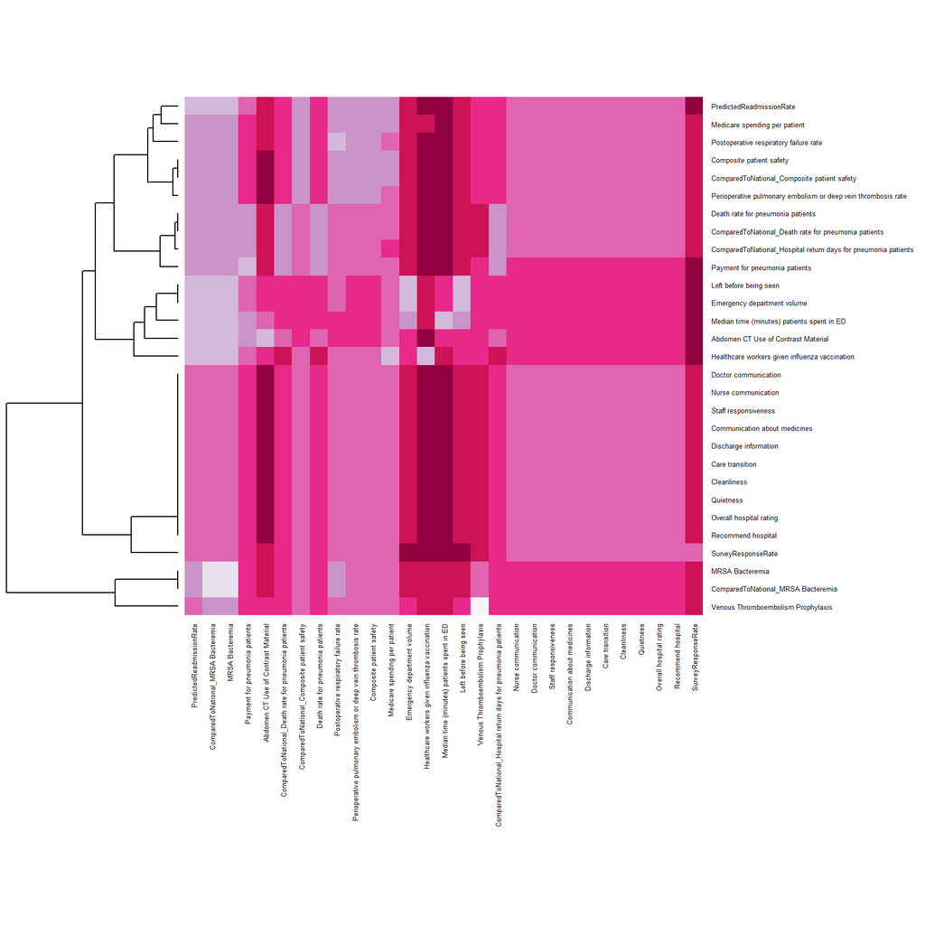

Figure 5. Correlation between Missing and Response

It may feel a little counterintuitive, but here **darker colors** indicate a higher correlation between missingness and response (proportions nearer to 1). In other words, these are the variables that are going to be more informative during imputation for a given variable.

But what if we wanted to know about patterns of missingness with regard to our target, `PredictedReadmissionRate`? Well, we could get that too!

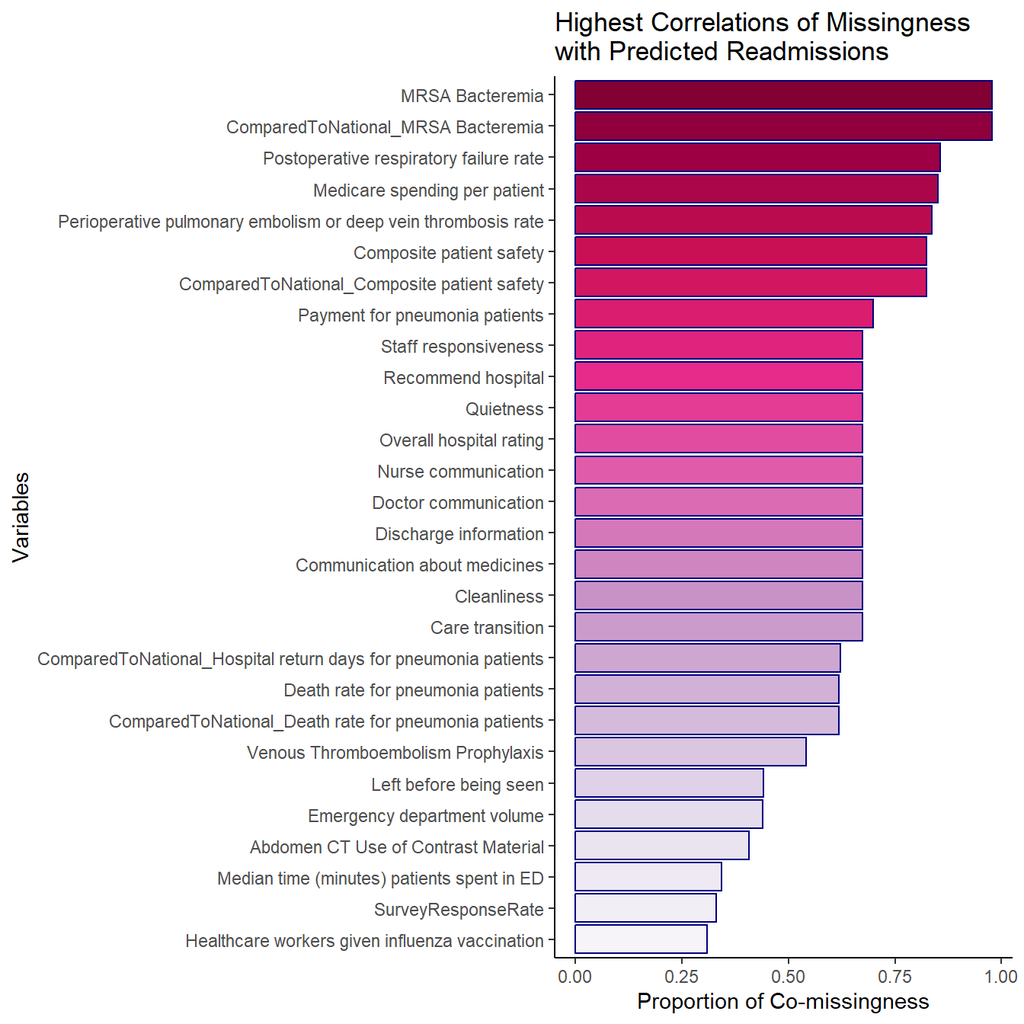

Figure 6. Correlation between Missing and Missing for Target

#### **Question 11B**: [0.5 points]

What columns seem to be most correlated in terms of missingness to our target, `PredictedReadmissionRate`? Does this give you any cause for concern? Feel free to speculate as to why you might see this.

> Your answer here. MRSA Bacteremia, but not sure why

## 3.3 Drop rows that are missing from the target variable.

We will not be able to use those rows at all moving forward, sadly. That is going to reduce our sample size pretty sizably, from $N = 4,816$ to only $N = 2,726$ (or from $N = 4,775$ to only $N = 2,731$ .

```
## [1] "Rows: 2726"  "Columns: 30"
```

#### **Question 12**: [0.5 points]

> Your answer here. I believe the dataset is still large enough to attempt a model. However, removing the rows with missing did lose almost half of the dataset.

## 3.4 Do the splits!

At this stage, we are almost ready to **impute** - but not until we have done our data partitioning first! In fact, splitting our data into training and testing partitions first is really important to prevent **data leakage**.

#### **Question 13**: [1 point]

Explain to your stakeholder, in simpler language, (1) why we partition data into testing and training sets and (2) what data leakage is. You do not need to go into great detail, but it should explain enough that they understand the basic ideas.

> Your answer here. Data is split into training test and testing sets. This is done so that the model can learn from one set of data, and we can than test the accuracy of the learned model on a new set of (unseen data). The new unseen data allows us to test the models prediction power on new and future data. Data leakage occurs when the training model has too much information, and the model has a performance theat is unrealistic with any new data.

You may recall that I mentioned that the optimal ratio is has been argued to be $\sqrt{p} : 1$, where $p$ is the number of parameters (which may or may not equal your predictors depending on your planned analysis). Note that you do not have to split only a single time; you could make different splits for different analyses, if needed. However, we are going to use a single split here for convenience.

Now, wouldn’t it be nice to have a handy function that could calculate the optimal split ratio for us? So, let’s write one! This is something you can use with ANY analysis going forward!

#### **Question 14A**: [1.5 points]

There are three parts to this question to get it to all come together correctly.

1. Comment the function to explain what it does (I’ve defined the arguments for you)
2. Run the function (fill in the blank)
3. Fill in the missing piece in the data partitioning chunk below

```r
calcSplitRatio <- function(p = NA, df) {
  ## @p  = the number of parameters. by default, if none are provided, the number of columns (predictors) in the dataset are used
  ## @df = the dataframe that will be used for the analysis

  ## p is equal to the number of columns in the dataframe - 1
  if(is.na(p)) {
    p <- ncol(df) -1   ## COMMENT HERE
  }

  ## the test number is equal to the 1/sqrt p * number of rows in our dataset (dat2Analyze)
  test_N <- (1/sqrt(p))*nrow(dat2Analyze)
  ## defining the proportion of the dataset that is the test partition
  test_prop <- round((1/sqrt(p))*nrow(dat2Analyze)/nrow(dat2Analyze), 2)
  ## defining the proportion of the dataset that is the training partition
  train_prop <- 1-test_prop

  ## the output that declares the ideal split ratio
  print(paste0("The ideal split ratio is ", train_prop, ":", test_prop, " training:testing"))

  ## the return of the function
  return(train_prop)
}

## Fill in the blanks to run:
train_prop <- calcSplitRatio(df=dat2Analyze)
```

```
## [1] "The ideal split ratio is 0.81:0.19 training:testing"
```

**Hint**: One important note here is that if the number of parameters are not provided (which is true for the starter code I gave you to run it - it does NOT pass any parameters to that argument!), then by default our function is designed to take the number of columns of the dataframe and subtract one for the target variable. Neat, huh?

Now, uncomment this code and fill it out to run it.

```r
 ind <- createDataPartition(dat2Analyze$PredictedReadmissionRate,   ## Put the target here!
                            p = train_prop,           ## Use the object you just made!
                            list = FALSE)

train <- dat2Analyze[ind, ]
test <- dat2Analyze[-c(ind), ]
```

#### **Question 14B**: [0.5 points]

What split ratio did you get? Is it close to the canonical 80-20 split? Why do you think that happened?

> Your answer here. The split ratio was 0.81:0.19 training:testing, which is very close to 80/20 split

```r
load(file = "FY2024_data_files/pneumoniaTrain.Rdata")
load(file = "FY2024_data_files/pneumoniaTest.Rdata")
```

## 3.5 Impute missing variables using `missForest`.

We are going to take advantage of the `missForest()` function from the `missForest` package. In a nutshell, what `missForest` does is it will fit either a regression- or classification-based random forest model and use the OOB (“out-of-bag”) results to predict and fill in `NA`s. The advantage is that this process is non-linear, done in just a few lines of code, and can handle mixed data-types (although you need to make sure that all your numerical types are of the same numerical type, and that all characters or factors are of the same type).

#### 3.5.1 Running `missForest`

The way I have chosen to do this is to separate the data so that I can turn the encoded categories back into categories temporarily, then stitch them back together into a temporary dataframe so that I can run `missForest`. Notice that I temporarily drop the `State` and target features; I drop `State` to spare ourselves a little computational time and I drop `PredictedReadmissionRate` to prevent **data leakage**. **Be patient!!**. Since this is randomForest, it could take a minute or two to run. **NOTE:** *If your machine fails to run this, there are data you can load. Some computers may struggle to run this.*

#### 3.5.2 Load this if it will not run for you

```r
load(file = "FY2024_data_files/imputedTrain.Rdata")
```

#### 3.5.3 Quick summary of the results

**NOTE:** If yours didn’t run, make sure to look at the table output in the knitted HTML I provided you. Also, change the `include=FALSE` in the chunk header if you were not able to get `missForest` to run.

#### **Question 15**: [1 point]

What does `MSE` (Mean Squared Error) and `PCF` (Proportion of Falsely Classified) indicate here? You may find looking at the `missForest` [Vignette](https://stat.ethz.ch/education/semesters/ss2012/ams/paper/missForest_1.2.pdf) helpful. Which variable(s) had the highest OOB error?

> Your answer here. MSE is the mean squared error of the imputation for missing data. a higher MSE indicates more error compared to true values. The variables with the highest OOB error were `Payment for pneumonia patients`, `Healthcare workers given influenza vaccination`, `Venous Thromboembolism Prophylaxis`, `ComparedToNational_Hospital return days for pneumonia patients`

**NOTE 1**: If the OOB error (either MSE or PCF) from `missForest` is really high, it’s a red flag that the imputation for those variables is untrustworthy. This could be do to too much missingness, weak relationships among the variables making it hard to predict, or low quality data (e.g., noisy, sparse). In such cases, we want to **DROP** any variables with extremely high OOB error because they add noise. A general rule of thumb is that if the PCF > ~0.3 (30% of the imputed values are wrong) or if there is especially high MSE (inflation) relative to the variance of the variable, we should drop it. Let’s set those aside so we can drop them from `test` and `train` both downstream!

**NOTE 2**: Even though the PCF is a bit too high, I am choosing to retain `ComparedToNational_Hospital return days for pneumonia patients` because it is a primary predictor. This could be a poor choice, however! Every decision we make as data scientists can *come with pitfalls*.

```r
## These look okay. Uncomment to see their variances.
#var(train$`Hospital return days for pneumonia patients`, na.rm = T)
#var(train$`Median time (minutes) patients spent in ED`, na.rm = T)
#var(train$`Healthcare workers given influenza vaccination`, na.rm = T)

cols2drop <- c("Payment for pneumonia patients", "Emergency department volume")
```

#### **Question 16**: [1 point]

Alternatively, we could use MICE (Multivariate Imputation with Chained Equations), which is a method that will model uncertainty along with the variables. Do a little research. How does MICE work? Include a citation to a source.

> Your answer here. Basic explanation of MICE https://www.machinelearningplus.com/machine-learning/mice-imputation/ #1. You basically take the variable that contains missing values as a response ‘Y’ and other variables as predictors ‘X’. #2. Build a model with rows where Y is not missing. #3. Then predict the missing observations. #Do this multiple times by doing random draws of the data and taking the mean of the predictions.

#### 3.5.4 Putting it alllllll back together…

We are almost done with imputation. The last thing we need to do is extract the imputed values from `imputed_data$ximp`, and add the `State` and target variable back. Then we get to wash, rinse, and repeat for the test set! Oh my!

##### 3.5.4.1 Put the original `State` and `target` variables back

```r
imputedTrain <- imputedTrain$ximp %>%
  ## Put the original State and target variables back on
  mutate(State = train$State,
         PredictedReadmissionRate = train$PredictedReadmissionRate)
```

##### 3.5.4.2 Now do the imputation for `test`

```r
# Remove encoded categorical variables for imputation, plus the target and state (which have no missing)
##data_sans_encoded = test %>%
##  select(-PredictedReadmissionRate,
##         -State,
##         -contains("ComparedToNational"))

##data_cat = test %>%
##  select(contains("ComparedToNational")) %>%
##  mutate_all(as.factor)

# Stitch them back together:
##temp <- cbind(data_sans_encoded, data_cat)

# Impute missing values using missForest
##imputedTest <- missForest(temp,
##                          variablewise = TRUE,
##                          verbose = FALSE)
```

##### 3.5.4.3 Load this if it will not run for you

```r
load(file = "FY2024_data_files/imputedTest.Rdata")
```

##### 3.5.4.4 Put the original `State` and `target` variables back on `test`

```r
imputedTest <- imputedTest$ximp %>%
  ## Put the original State and target variables back on
  mutate(State = test$State,
         PredictedReadmissionRate = test$PredictedReadmissionRate)
```

##### 3.5.4.5 Drop the features we determined we should not retain due to unstable imputation from BOTH `train` and `test`

```r
imputedTrain <- imputedTrain[, !(names(imputedTrain) %in% cols2drop), drop = FALSE]
imputedTest  <- imputedTest[, !(names(imputedTest) %in% cols2drop), drop = FALSE]
```

#### **Question 17**: [1 point]

Quickly explore how well the imputation did by choosing at least one numeric variable and one of the categorical variables. Did the distributions or frequencies change drastically? You may find the `summary()` and `table()` functions to be fastest here.

```r
# Your code here.
summary (imputedTrain$`MRSA Bacteremia`)
```

```
##    Min. 1st Qu.  Median    Mean 3rd Qu.    Max.
##  0.0000  0.4790  0.7750  0.8088  1.0576  4.6910
```

```r
summary (imputedTrain$`ComparedToNational_MRSA Bacteremia`)
```

```
##   -1    0    1
##   41 2029  140
```

> Your answer here. Distributions are similar

## 3.6 Another Fork in the Road

It’s time, yet again, to make a choice. If you opted to load the **fully encoded** dataset and everything has been done on that, you will run the first chunk. But if you decided that you wanted to **wait to encode** the TIME HAS FINALLY COME!

### 3.6.1 The Left Fork - No Encoding, Just Converting Data Back After `missForest`

Ultimately, we need to turn the factor features back into numbers for our next analyses but we had to turn them into factors for `missForest`. So, now we need to turn them back. Notice a bit of annoying trickery here. Because we had converted them to a factor type, in order to back-convert them correctly to our original ordinal encoding, we had to first convert to character and then to numeric. So, our conversion goes **factor** $\rightarrow$ **character** $\rightarrow$ **numeric** in order to get exactly what we need! Again, we must remember to perform on BOTH `imputedTrain` and `imputedTest`.

```r
## Uncomment if this is your choice!
readyTrain <- imputedTrain %>%
   mutate_if(is.factor, as.character) %>%
   mutate_if(is.character, as.numeric)

 readyTest <- imputedTest %>%
   mutate_if(is.factor, as.character) %>%
   mutate_if(is.character, as.numeric)
```

### 3.6.2 The Right Fork - Frequency Encoding

The time has FINALLY come to do frequency encoding, if that is the fork in the road you took all the way back in Section 1.3. Once again, we will be using a helper function that we load with the `source()` function like we did here. It will do the frequency encoding for us on the `State` variable, if it needs to be done. If you started from the fully encoded dataset, there is a conditional statement that will skip this for you.

```r
## This calls the helper function in the associated .R file
source(file = "doFrequencyEncoding.R")

## If State is not already a number
if(!is.numeric(imputedTrain$State)) {
    ## This sets a list of COLUMN NAMES I want to frequency encode
    cols2encode <- c("State")

    ## This runs the function, which takes up to 4 arguments
    ## Open the source code to see what each argument does!
    ## It returns a LIST of frequency encoded dataframes.
    freqEncoded <- doFrequencyEncoding(train = imputedTrain,
                                       test = imputedTest,
                                       cols2encode = cols2encode,
                                       quiet = FALSE)

    ## Lastly, extract the newly encoded, imputed, dataframes!
    readyTrain <- freqEncoded$train
    readyTest <- freqEncoded$test
}
```

#### **Question 18**: [1 point]

Because we are now frequency encoding AFTER data partitioning (we did ordinal encoding BEFORE the split for convenience), we absolutely **must** apply the same encoding map to the `test` set that we did to the `train` set. Explain why, and what should we do if some classes of the variable end up in the `train` that is not in the `test` or vice versa? (**HINT**: Look at the source code!)

> Your answer here. Probably could shuffle the data and split again in an effort to have classes represented on both sides of the split.

## 3.7 Transformation & Scaling

Ultimately, we know we will need to scale & center our data, as that is required for the analyses I have set out in our Analysis Plan. But before we get into that, it would be nice to know what **realm of analyses** in which we fall and, more importantly, do we need to consider *transformation* of our target in addition to the scaling & centering we plan to do on the entire dataset.

**In other words: is our target variable approximately normally distributed?**

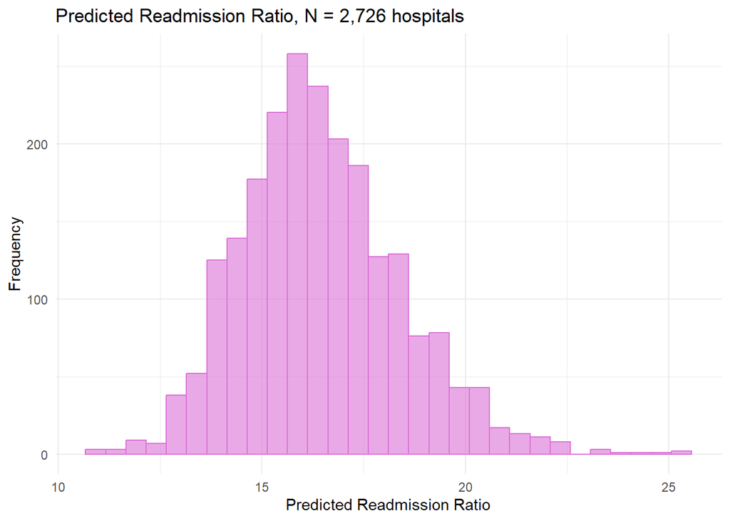

Figure 7. Histogram of Raw Predicted Readmission Rate

#### **Question 19A**: [1 point]

Why is a histogram, or even a Q-Q plot, an insufficient way to assess whether a distribution is approximately normal?

> Your answer here. According to information found on the web, a histogram can be influenced by bin size (so may or may not appear as a normal distribution, depending on bin size chosen. Q-Q plots may also have small deviations that can be difficult to interpret)

Now Apply a [Shapiro-Wilk test](https://biostats.w.uib.no/test-for-normality-shapiro-wilks-test/) for normality using the `shapiro.test()` function. What does it indicate about your distribution? (**Note**: Shapiro tests are only reliable for $N < 5000$, but it is fine to perform here.)

```r
# Your code here.

shapiro.test(readyTrain$PredictedReadmissionRate)
```

```
##
##  Shapiro-Wilk normality test
##
## data:  readyTrain$PredictedReadmissionRate
## W = 0.98544, p-value = 0.00000000000003085
```

> Your answer here. Since the p-value produced by the Shapiro-Wilk test is not greater than 0.05, the distribution of the target is NOT normally distributed.

### 3.7.1 Box-Cox Transformation

The Box-Cox transformation is a *family* of power transformations used to stabilize variance and make data more normally distributed (Box & Cox, 1964). Recall from our brief discussion in lecture that the Box-Cox transformation involves the parameter $\lambda$, which when applied to $y$ yields the transformation. It is defined as

$y^\lambda = \frac{y^\lambda - 1}{\lambda}$ for $\lambda \ne 0$.

When $\lambda = 0$, it is the same as the $\ln(y)$. Our lecture slides have more reference values for how to interpret $\lambda$. But if $\lambda \ne 0$, then this means that the transformation is only applicable to positive values. The end result is that it helps improve the performance of statistical models that assume normality.

#### 3.7.1.1 There are multiple ways to apply the Box-Cox transform in R, but we are going to take advantage of the one in `caret` to make our lives easier, `BoxCoxTrans()`.

```r
bc_data <- BoxCoxTrans(readyTrain$PredictedReadmissionRate)
print(paste0("Box-Cox lambda =  ", bc_data$lambda))
```

```
## [1] "Box-Cox lambda =  -0.3"
```

#### 3.7.1.2 Now, apply the Box-Cox transformation to the `train` data:

```r
readyTrain$bc_PredictedReadmissionRate <- predict(bc_data, readyTrain$PredictedReadmissionRate)
```

#### 3.7.1.3 Assess how it did:

[figure not shown]

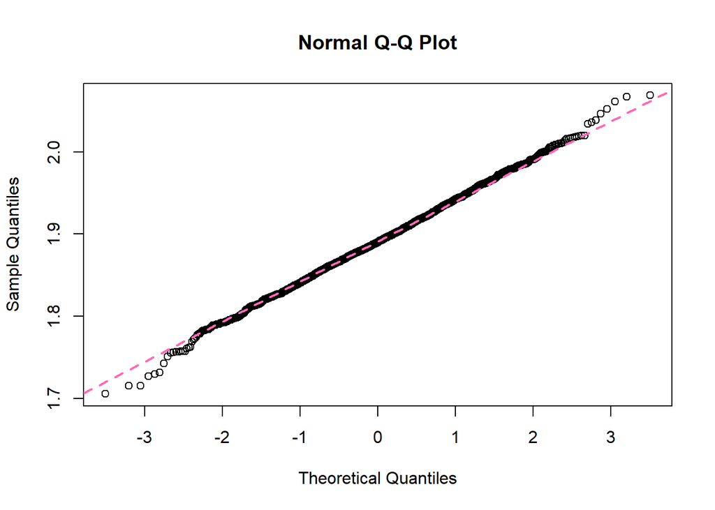

##### Figures 8a-b. Predicted Readmission Rate After Box-Cox Transformation

Can you see what it did to the distribution? **look closely**, if not. It’s subtle but discernible!!